# ME-NH Inshore Trawl Survey Abundance Indices Code: All Species

Rebecca Peters

12/13/2019

## Trawl Survey Data Analysis

This document explains how to pull data out from Marvin and run analysis to develop abundance and biomass indices for all species that are caught in the trawl survey.

If you just need to calculate abundance indices for one species, calculate catch at length, and make distribution plots please view the html here. Hint: right click on the link and click open in browser if it doesn’t take you to the link.

For most of the species caught in the trawl survey catch from all four depth stratum is included in the analysis. Indices for American lobster and winter flounder are generated using catch from depth stratums 1-3. American lobster may be including the fourth depth stratum in the future. Indices for rainbow smelt only uses catch from depth stratums 1 and 2.

## Abundance Indices

### Step 1: Load libraries

The first thing to do is load all of the libraries needed to run the code

```r
library(RODBC)
library(stringr)
library(xlsx)
library(ggplot2)
library(latticeExtra)
library(gridExtra)
library(grid)
library(lemon)
library(tidyr)
library(devtools)
library(dplyr)
library(ggpubr)
```

### Step 2: Connect to Marvin

There are multiple ways to connect to Marvin. Below I put the code in that I use to connect to Marvin. Bill has created another way to connect. In this code I am using Marvin64 for the 64bit version of R. If you are using the 32 bit version of R then the dsn will just be MARVIN. The uid and pwd will need to be changed to your Marvin username and password.

Note - here the marvin username and password are stored in my environmental variables on the computer so it keeps them private. You can choose to put your username and password in the code below to connect to Marvin or you can define your Marvin username and password in the environmental variables on your computer and use this code to connect to Marvin.

```r
Marvin=odbcConnect(dsn="MARVIN64", uid=Sys.getenv("marvin_user"), pwd=Sys.getenv("marvin_pw"))
```

### Step 3: Pulling out data from Marvin

The code below will pull out all the data needed from Marvin to run the analysis. When you get to the species portion of the code you will realize that I select which species to pull out from the data. You will have to change the Species ITIS code when running this code to get data out for the specific species you want.

```r
#FIRST you need to pull out the trip data form Marvin
SurveySql=paste(
  "select PROJECT_NAME,",
  "TRIP_SEQ_NO,",
  "DMR_TRIP_IDENTIFIER,",
  "TRIP_START_DATE,",
  "TRIP_END_DATE",
  "from MARVIN.MV_GFT_TRIP",
  sep=" "); SurveySql

SurveySql=str_to_upper(SurveySql)

Surveys=sqlQuery(channel=Marvin,
                 query=SurveySql,
                 stringsAsFactors=FALSE)
```

Now the columns of the survey data just pulled out willed be change and a string of survey IDs are created to pull these surveys out from the effort table.

```r
names(Surveys)=c("Project", "SurveyID", "Survey", "StartDate", "EndDate")
head(Surveys)
TripString.S=toString(paste("'", sort(unique(Surveys$SurveyID)), "'", sep=""))
```

Next - run query to pull out effort data from Marvin in the GFT_Effort table and the columns get renamed.

```r
S.EffortSql=paste(
  "select TRIP_SEQ_NO,", #SurveyID
  "EFFORT_SEQ_NO,", #UniqueTowID
  "DMR_EFFORT_IDENTIFIER,", #TowNum
  "EFFORT_START_DATE,", #Start_Date
  "EFFORT_END_DATE,", #End_Date
  "LENGTH_TOW_TIME,", #Tow_Time
  "GRID_ID,", #Grid_ID
  "REGION,", #Region
  "STRATUM,", #Stratum
  "START_LATITUDE,", #start_Lat
  "START_LONGITUDE,", #Start_Lon
  "END_LATITUDE,", #End_Lat
  "END_LONGITUDE,", #End_lon
  "START_DEPTH,", #Start_depth
  "END_DEPTH,", #End_depth
  "AVERAGE_DEPTH,", #Avg_depth
  "STATION_TYPE,", #Station_Code
  "TOW_LENGTH_NM", #Tow_LengthNM
  "from MARVIN.MV_GFT_EFFORT",
  "where TRIP_SEQ_NO in(",TripString.S,")",
  sep=" "); S.EffortSql

S.Effort=sqlQuery(channel=Marvin,
                  query=S.EffortSql,
                  stringsAsFactors=FALSE); summary(S.Effort)
head(S.Effort) #checking to see what is there#

names(S.Effort)=c("SurveyID", "UniqueTowID", "TowNum", "Start_Date", "End_Date", "Tow_Time",
                  "Grid_ID", "Region", "Stratum", "start_lat", "start_lon", "end_lat",
                  "end_lon","start_depth", "end_depth", "avg_depth", "station_code",
                  "Tow_LengthNM")

head(S.Effort)
```

The survey data pulled out is in the seperate dataframe than the effort data pulled out of Marvin so the dataframes are then merged back together.

```r
TrawlSurvey.E=merge(S.Effort, Surveys[ ,c("SurveyID", "Survey")]); head(TrawlSurvey.E)
```

Species data is queried out from the Marvin Species table and the name of the columns are changed.

```r
##querying out species names#
SpeciesSql=paste(
  "select SPECIES_ITIS_CODE,",
  "COMMON_NAME,",
  "SCIENTIFIC_NAME",
  "from MARVIN.SPECIES",
  sep=" "); SpeciesSql

Species=sqlQuery(channel=Marvin,
                 query=SpeciesSql,
                 stringsAsFactors=FALSE); summary(Species)
names(Species)=c("Species_Code", "Common_name", "Scientific_name"); head(Species)
```

Next the catch data is queried out and column headers are changed.

```r
S.CatchSql=paste(
  "select EFFORT_SEQ_NO,",
  "CATCH_SEQ_NO,",
  "DMR_CATCH_IDENTIFIER,",
  "SPECIES_ITIS_CODE,",
  "REPORTED_QUANTITY,",
  "CATCH_WEIGHT,",
  "CATCH_WEIGHT_TYPE,",
  "CATCH_WEIGHT_UNIT,",
  "SUBSAMPLE_WEIGHT,",
  "WEIGHT_MALES,",
  "WEIGHT_FEMALES",
  "from MARVIN.MV_GFT_CATCH",
  sep = " "); S.CatchSql

S.Catch=sqlQuery(channel=Marvin, query=S.CatchSql, stringsAsFactors=FALSE); summary(S.Catch)
names(S.Catch)=c("UniqueTowID", "Catch_seq", "DMR_Catch_ID", "Species_Code", "NumberCaught",
                 "Weight", "Catch_Weight_Type","Catch_Weight_Unit", "Subsample_Weight",
                 "Male_weights", "female_weights")
```

Now these dataframes will be merged together. First the catch dataframe is merged with the species dataframe so the species name is shown in the catch dataframe.

```r
Catch_data<-merge(Species, S.Catch, by="Species_Code", all.y=TRUE)
```

Then the new catch_data dataframe is merged with the effort (TrawlSurvey.E) dataframe. The reason this is done stepwise is to make sure all tows are included in the dataframe, even tows where the species of interest was not caught. You need to have zeros included in the dataframe to get average catch/weight per tow.

```r
Catch_data.2 <- merge(TrawlSurvey.E, Catch_data, by="UniqueTowID", all.x=TRUE)
#next run this code so the data is in ascending order##
Catch_data.2<-arrange(Catch_data.2, Survey, TowNum, Common_name)
```

### Step 4: Editing the data so it can be analyzed

The next step will format the data to change the station_code that is labled NA for non-random alternate to NR so R doesn’t think these are actual NA values. Then after that the, NA’s in the NumberCaught and Weight column are changed to 0 so zero catches are included in the dataframe.

```r
Catch_data.2$station_code<-as.character(Catch_data.2$station_code)
Catch_data.2$station_code<-ifelse(is.na(Catch_data.2$station_code), "NR",
                                  Catch_data.2$station_code)
#adding in 0's for the NA in the NumberCaught and weight column to do analysis#
Catch_data.2$NumberCaught<-ifelse(is.na(Catch_data.2$NumberCaught), "0", Catch_data.2$NumberCaught)
Catch_data.2$Weight<-ifelse(is.na(Catch_data.2$Weight), "0", Catch_data.2$Weight)
```

Anywhere in the dataframe where the species of interest was not caught the catch data has NAs in it. The common_name and scientific_name column will have NAs so the common name and scientific name for those species is added into those columns where NAs are present.

```r
##now add in scientific name instead of NA
Catch_data.2$Scientific_name<-ifelse(is.na(Catch_data.2$Scientific_name), "Gadus morhua",
                                     Catch_data.2$Scientific_name)
##now adding in common name instead of NA#
Catch_data.2$Common_name<-ifelse(is.na(Catch_data.2$Common_name), "cod atlantic",
                                 Catch_data.2$Common_name)
##now rearranging data columns to make more sense#
Catch_data.2<-Catch_data.2[c("Survey", "TowNum", "Region", "Stratum", "Grid_ID", "Common_name",
                             "Scientific_name", "NumberCaught", "Weight", "Catch_Weight_Type",
                             "Catch_Weight_Unit", "Subsample_Weight", "Male_weights",
                             "female_weights", "station_code", "Start_Date", "End_Date",
                             "start_lat", "start_lon", "end_lat", "end_lon", "start_depth",
                             "end_depth", "avg_depth", "Tow_Time", "Tow_LengthNM", "SurveyID",
                             "Species_Code", "UniqueTowID", "Catch_seq", "DMR_Catch_ID")]
```

### Step 5: Sum together the catch for species that have two entries in Marvin.

For certain species (American lobster - berried vs other lobsters, alewives - large and small, dogfish - from FL05 to SP13 two seperate entries for male and female dogfish) catches in a tow where they occur are entered into Marvin seperately. The code below will sum those species together and create new columns. Since a new dataframe was created when the data was summed up the new Sums dataframe is merged back with the original Catch_data.2 dataframe so the catch_sum and weight_sum columns are included in the maine dataframe with effort data.

```r
#need to make sure that the numbercaught and weight column is numeric and if not need to convert them to numeric
str(Catch_data.2)
Catch_data.2$NumberCaught<-as.numeric(as.character(Catch_data.2$NumberCaught))
Catch_data.2$Weight<-as.numeric(as.character(Catch_data.2$Weight))

Sums<-Catch_data.2 %>%
  group_by(Survey, TowNum, Common_name) %>%
  summarize(catch_sum = (sum(NumberCaught)), weight_sum=(sum(Weight)))
Survey_Catch_Sums<-merge(Catch_data.2, Sums, by=c("Survey", "TowNum", "Common_name"), all=TRUE)
head(Survey_Catch_Sums)
#in the code below we are rearraning the dataframe so that the columns are in order.
Survey_Sums<-Survey_Catch_Sums[c("Survey", "TowNum", "Region", "Stratum", "Grid_ID", "Common_name",
                                 "Scientific_name", "NumberCaught", "catch_sum",
                                 "Weight","weight_sum", "Catch_Weight_Type", "Catch_Weight_Unit",
                                 "Subsample_Weight", "Male_weights",
                                 "female_weights","station_code","Start_Date", "End_Date",
                                 "start_lat", "start_lon", "end_lat", "end_lon", "start_depth",
                                 "end_depth", "avg_depth", "Tow_Time", "Tow_LengthNM", "SurveyID",
                                 "Species_Code", "UniqueTowID", "Catch_seq", "DMR_Catch_ID")];
Survey_Sums<-arrange(Survey_Sums, Survey, TowNum, Common_name); head(Survey_Sums)
#now remove columns that are not needed and rename the dataframe.
Survey_Catch<-dplyr::select(Survey_Sums, -SurveyID, -Species_Code, -UniqueTowID,  -DMR_Catch_ID)
head(Survey_Catch)
```

### Step 6: Create a time expansion factor column so you can standardize the catch data to twenty minute tows.

The next step will be to create a new column with a time expasion factor (column name will be Tow_Time_Exp) for any tow that was under or over twenty minutes. If a tow was twenty minutes the expansion factor will be 1. This is needed to standardize the catch data so it can be compared between tows and used in analysis.

```r
#The functions below will change the Tow_Time column from the time format it is in
#to just a regular variable (i.e. from 00:20 to just 20)
Survey_Catch$Tow_Time<-as.numeric(substring(Survey_Catch$Tow_Time,first=4,last=5))
Survey_Catch$Tow_Time_Exp<-(20/60)/(Survey_Catch$Tow_Time/60)
#this line of code checks that you have a 20 minute tow after the calculations
Survey_Catch$Std_dur<-Survey_Catch$Tow_Time_Exp*Survey_Catch$Tow_Time
head(Survey_Catch)
```

### Step 7: Standardize catch and weight

Next you will multiply the catch and weight data by the time expansion factor to create expanded catch and expanded weight columns. The expanded catch and weight is what is used to calculate indices.

```r
##now expand all the catch and weight and add in new columns for these expansions.
Survey_Catch$EXP_Catch<-(Survey_Catch$catch_sum * Survey_Catch$Tow_Time_Exp)
Survey_Catch$EXP_Weight<-(Survey_Catch$weight_sum * Survey_Catch$Tow_Time_Exp)
head(Survey_Catch)
```

### Step 8: Remove data that is not used in the analysis and create a smaller dataframe

The line of code below removes fixed and duplicate sites from the dataset since these are not included in the analysis. If you need to remove survey strata you will use similar code but just specify what needs to be removed.

```r
Strat4_Catch<-subset(Survey_Catch, station_code != "F" & station_code != "D")
Strat4_Catch$Year=as.numeric(paste0("20", substr(Strat4_Catch$Survey, 3, 4)))
head(Strat4_Catch)
#example of code to remove another depth stratum
#Strat3_Catch<-subset(Strat4_Catch, Stratum != "4")
```

Now only select the columns needed to calculate abundance indices and remove duplicates that were created when the data was summed.

```r
Strat4_Catch<-select(Strat4_Catch, Survey, TowNum, Region, Stratum, Common_name, Scientific_name,
                     EXP_Catch, EXP_Weight, Year)
catch.removeduplicates<-dplyr::distinct(Strat4_Catch, Survey, TowNum, Region, Stratum, Common_name,
                                        Scientific_name, .keep_all=TRUE)
```

Then add in zeros for when a species wasn’t caught in a tow of a specific survey. You need to do this to calculate averages, variance, and standard deviation.

```r
Strat4_Catch <- catch.removeduplicates %>%
  complete(nesting(Survey, TowNum, Region, Stratum, Year), nesting(Common_name, Scientific_name),
           fill=list(EXP_Catch=0, EXP_Weight=0))
```

### Step 9: Start calculating mean, variance, and standard deviation of catch and weight by region and stratum

The line of code below calculates the mean, variance, and standard deviation of catch and weight for each survey by region and stratum. This is the first step in calculating stratified mean abundance and biomass.

```r
Stratum.means<-Strat4_Catch %>%
  group_by(Survey, Region, Stratum, Common_name, Scientific_name) %>%
  summarize(average_catch_exp = (mean(EXP_Catch, na.rm=TRUE)),
            average_weight_exp=(mean(EXP_Weight, na.rm=TRUE)),
            variance_catch_exp = (var(EXP_Catch, na.rm=TRUE)),
            variance_weight_exp=(var(EXP_Weight, na.rm=TRUE)),
            sd_catch_exp = (sd(EXP_Catch, na.rm=TRUE)),
            sd_weight_exp=(sd(EXP_Weight, na.rm=TRUE)),
            count_catch = (length(na.omit(EXP_Catch))),
            count_weight=(length(na.omit(EXP_Weight))))
```

### Step 10: Load in strata area file from the X drive

The code below loads in the csv with the strata area to calculate the abundance and biomass indices. Then this file is merged with the Stratum.means dataframe created above.

```r
area<-read.csv("X:/Trawl/Abundance Indices/Survey_Area.csv", header=T); head(area)
names(area)<-c("Region", "Stratum", "Area_sqMI", "Area_Hectare", "Area_SqKM"); head(area)

Avg.includingarea=merge(Stratum.means, area, by=c("Region", "Stratum"), all=TRUE)
```

### Step 11: Calculate stratum totals and associated variances

```r
StratumTotals <- Avg.includingarea %>%
  mutate(AverageCatch_byarea = (average_catch_exp * Area_SqKM),
         AverageWeight_byarea =(average_weight_exp * Area_SqKM),
         VarCatch_Tst=(((variance_catch_exp)/count_catch) * (Area_SqKM^2)),
         VarWeight_Tst=(((variance_weight_exp)/count_weight) * (Area_SqKM^2)),
         catchvar=(variance_catch_exp * (Area_SqKM^2)),
         weightvar=(variance_weight_exp * (Area_SqKM^2)))

TotalStratMean<-StratumTotals %>%
  group_by(Survey, Common_name, Scientific_name) %>%
  summarize(sumof_averageCatchbyarea = (sum(AverageCatch_byarea, na.rm=TRUE)),
            sumof_averageWeightbyarea=(sum(AverageWeight_byarea, na.rm=TRUE)),
            sumof_VarCatch = (sum(VarCatch_Tst, na.rm=TRUE)),
            sumof_VarWeight = (sum(VarWeight_Tst, na.rm=TRUE)),
            sumof_catchvar = (sum(catchvar, na.rm=TRUE)),
            sumof_weightvar = (sum(weightvar, na.rm=TRUE)))
head(TotalStratMean)
```

### Step 12: Calculate the stratified mean abundance and biomass for each survey.

For this the year in addeding in for the following steps.

The year column is needed to seperate out the years where only three strata were surveyed. There were only three depth stratas in the first few years of the survey (2000-2002). Starting in 2003 a fourth depth stratum was added which changed the total survey area. Prior to 2003 the total survey area listed in docouments was 9000.0792 square km. If you add up the three depth stratums in the area file loaded in this script you will notice that the sum is different than the listed area. Since the survey area was updated in 2019 to account for areas of the survey that can no longer be surveyed due to hard bottom, the listed total survey area is used for the surveys from 2000 - 2002 instead of the sum of the three depth stratums. It is unknown how the survey area was calculated prior to 2003 when only three depth stratums were included and how the survey area may have changed once the fourth stratum was added. For these reasons the listed area is used to calculate the abundance indices for the 2000 - 2002 surveys.

To calculate the stratified mean abundance and biomass for each survey you will take the total stratified means calculated above and multiply that by the total survey area to account for the survey area. The variance of the stratified means also needs to be weighted by total survey area. The total survey area for fourth depth stratas (in squareKM) is 11774.98. For three depth stratas it is 9073.245. You can check that is is correct by summing up the Area_SqKM column from the area file loaded in earlier, which is done below.

You will see in this code below that the stratified mean is calculated for four depth stratas. I’ve included the code for the calculation for when you only need to use three depth strats in the calculation, but it is hashtagged out. If you need this just unhashtag those lines of code and make sure to hashtag the StratMean.4strata out.

```r
TotalStratMean$Year=as.numeric(paste0("20", substr(TotalStratMean$Survey, 3, 4)))

#check total survey area#
TotalSurveyArea_4strata<-area %>%
  summarize(TotalAreaSurveyed_SqKM = sum(Area_SqKM))
TotalSurveyArea_3strata<-area %>%
  subset(Stratum != "4") %>%
  summarize(TotalAreaSurvey_SqKM = sum(Area_SqKM))

StratMean.3strata<- TotalStratMean %>%
  filter(Year < 2003) %>%
  mutate(StratMean_Catch = sumof_averageCatchbyarea/9000.0792,
         StratMean_Weight=sumof_averageWeightbyarea/9000.0792,
         varMst_Catch = (sumof_VarCatch/(9000.0792^2)),
         varMst_Weight=(sumof_VarWeight/(9000.0792^2)),
         varforCV_Catch = (sumof_catchvar/(9000.0792^2)),
         varforCV_Weight=(sumof_weightvar/(9000.0792^2)))

StratMean.4strata<- TotalStratMean %>%
  filter(Year >= 2003) %>%
  mutate(StratMean_Catch = sumof_averageCatchbyarea/11774.98,
         StratMean_Weight=sumof_averageWeightbyarea/11774.98,
         varMst_Catch =(sumof_VarCatch/(11774.98^2)),
         varMst_Weight=(sumof_VarWeight/(11774.98^2)),
         varforCV_Catch = (sumof_catchvar/(11774.98^2)),
         varforCV_Weight=(sumof_weightvar/(11774.98^2)))

##just using three strata below
#StratMean.3strata.2<- TotalStratMean %>%
#  filter(Year >= 2003) %>%
#  mutate(StratMean_Catch = sumof_averageCatchbyarea/9073.245,
#         StratMean_Weight=sumof_averageWeightbyarea/9073.245,
#         varMst_Catch =(sumof_VarCatch/(9073.245^2)),
#         varMst_Weight=(sumof_VarWeight/(9073.245^2)),
#         varforCV_Catch = (sumof_catchvar/(9073.245^2)),
#         varforCV_Weight=(sumof_weightvar/(9073.245^2)))

##now combine these two dataframes using rbind to have all the data in one dataframe##
AbundanceIndices<-rbind(StratMean.3strata, StratMean.4strata)
#just for three strata#
#AbundanceIndices<-rbind(StratMean.3strata, StratMean.3strata.2)
```

### Step 13: Calculating standard error and 95% confidence intervals

The code chunk below will calculate the standard error and confidence interval for each mean and add those columns into the AbundanceIndices dataframe added above.

```r
AbundanceIndices$SE_Catch<-(sqrt(AbundanceIndices$varMst_Catch))
AbundanceIndices$CI_Catch<-2*AbundanceIndices$SE_Catch
AbundanceIndices$CV_Catch<-(sqrt(AbundanceIndices$varforCV_Catch))/
  AbundanceIndices$StratMean_Catch
AbundanceIndices$SE_Weight<-(sqrt(AbundanceIndices$varMst_Weight))
AbundanceIndices$CI_Weight<-2*AbundanceIndices$SE_Weight
AbundanceIndices$CV_Weight<-(sqrt(AbundanceIndices$varforCV_Weight))/
  AbundanceIndices$StratMean_Weight
AbundanceIndices$Low_CI_Catch<-(AbundanceIndices$StratMean_Catch - AbundanceIndices$CI_Catch)
AbundanceIndices$High_CI_Catch<-(AbundanceIndices$StratMean_Catch + AbundanceIndices$CI_Catch)
AbundanceIndices$Low_CI_Weight<-(AbundanceIndices$StratMean_Weight - AbundanceIndices$CI_Weight)
AbundanceIndices$High_CI_Weight<-(AbundanceIndices$StratMean_Weight + AbundanceIndices$CI_Weight)
```

After adding in those columns you will take out the columns not needed in the dataframe and arrange the column in logical order for exporting purposes.

```r
Trawl.Indices<-dplyr::select(AbundanceIndices, -sumof_averageCatchbyarea,
                             -sumof_averageWeightbyarea, -sumof_VarCatch,
                             -sumof_VarWeight, -sumof_VarCatch, -sumof_VarWeight)
Trawl.Indices<-Trawl.Indices[c("Survey", "Common_name", "Scientific_name", "StratMean_Catch","CV_Catch",
                               "SE_Catch","Low_CI_Catch",
                               "High_CI_Catch", "varMst_Catch", "StratMean_Weight", "CV_Weight",
                               "SE_Weight", "Low_CI_Weight", "High_CI_Weight", "varMst_Weight")]
Trawl.Indices<-arrange(Trawl.Indices, Survey)
#write.xlsx(Trawl.4strata.indices, file="SPECIESNAME_indicessupport.xlsx", col.names=TRUE,
#row.names=TRUE, append=FALSE)
```

### Step 14: Add in new columns for plotting and plot the indices and save an Rdata file

The first thing you’ll need is to add in a season and year column to seperate the plots by season and have an x axis by year

```r
Trawl.Indices$Season <- substring(Trawl.Indices$Survey,first=1,last=2)
Trawl.Indices$Year<-as.numeric(paste0("20", substring(Trawl.Indices$Survey, 3, 4)))
```

Now that all the abundance indices are calculated for each species you can save an Rdata file of the Trawl.Indices dataframe and then load it into another R session to develop any plots you may want. Just make sure to specify where you want the Rdata file saved. Below I have it saved in the project directory this file is created in, but you have specify what drive and folder you want it sent to by modifying the code.

```r
save(Trawl.Indices, file = "MENH_InshoreTrawlSurvey_Indices.RData")
```

Then you’ll use ggplot to plot indices by season for any species you select. For each season there will be two graphs on one large plot. The abundance indces will be on the top and the biomass indices will be on the bottom. For each different species you’ll have to adjust the y axis to make it look the way you want. You can choose to edit these however you wish. #### Spring plot:

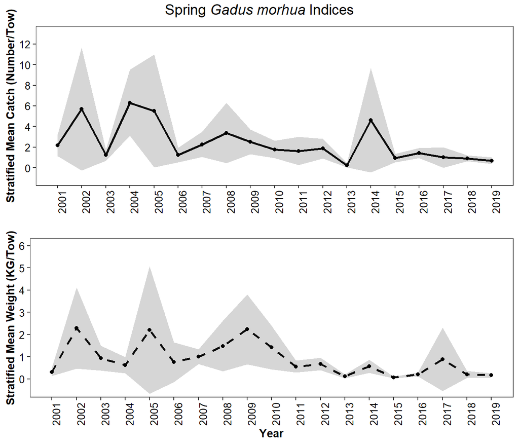

```r
Spring<-subset(Trawl.Indices, Season =="SP" & Common_name == "cod atlantic")
SpringCatch<-ggplot(data=Spring, aes(x=Year, y=StratMean_Catch)) + geom_line( size=1) +
  geom_ribbon(aes(ymin=Low_CI_Catch, ymax=High_CI_Catch), linetype=2, alpha=0.2) +
  theme_bw() + theme(panel.grid.major = element_blank(), panel.grid.minor = element_blank()) +
  scale_x_continuous(name="", breaks=c(2000:2019)) +
  geom_point(colour="#000000")  +
  theme(axis.text.x = element_text(color="#000000", size=10, angle=90),
        axis.text.y = element_text(color="#000000", size=10)) +
  theme(axis.title.x = element_text(size=11, face="bold")) +
  theme(axis.title.y=element_text(size=11, face="bold")) +
  scale_y_continuous(name="Stratified Mean Catch (Number/Tow)",
                     breaks=seq(0, 12, 2),limits=c(-1,13),oob=scales::rescale_none)

SpringWeight<-ggplot(data=Spring, aes(x=Year, y=StratMean_Weight)) +
  geom_line(linetype=2, size=1) +
  geom_ribbon(aes(ymin=Low_CI_Weight, ymax=High_CI_Weight), linetype=2, alpha=0.2)+
  theme_bw() + theme(panel.grid.major = element_blank(), panel.grid.minor = element_blank()) +
  scale_x_continuous(name="Year", breaks=c(2000:2019)) +
  geom_point(colour="#000000")  +
  theme(axis.text.x = element_text(color="#000000", size=10, angle=90), axis.text.y =
          element_text(color="#000000", size=10)) +
  theme(axis.title.x = element_text(size=11, face="bold")) +
  theme(axis.title.y=element_text(size=11, face="bold")) +
  scale_y_continuous(name="Stratified Mean Weight (KG/Tow)", breaks=seq(0, 6, 1),
                     limits=c(-0.5,6), oob=scales::rescale_none)

titlespring=textGrob(expression(paste("Spring", italic(" Gadus morhua "), "Indices")), gp=gpar(fontface="bold", fontsize=14))
grid.arrange(SpringCatch, SpringWeight, ncol=1, top=titlespring)
```

#### Fall plot:

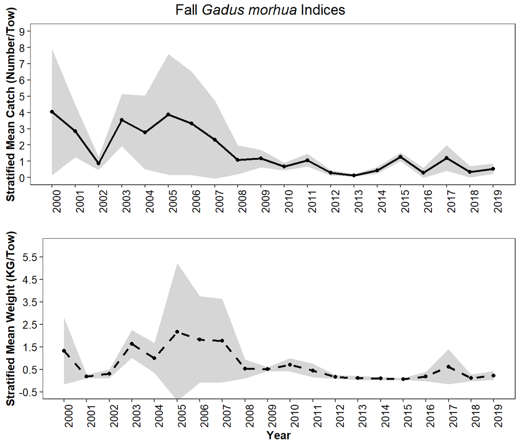

```r
Fall<-subset(Trawl.Indices, Season=="FL" & Common_name == "cod atlantic")
Fallcatch<-ggplot(data=Fall, aes(x=Year, y=StratMean_Catch)) + geom_line( size=1) +
  geom_ribbon(aes(ymin=Low_CI_Catch, ymax=High_CI_Catch), linetype=2, alpha=0.2) +
  theme_bw() + theme(panel.grid.major = element_blank(), panel.grid.minor = element_blank()) +
  scale_x_continuous(name="", breaks=c(2000:2019)) +
  geom_point(colour="#000000")  +
  theme(axis.text.x = element_text(color="#000000", size=10, angle=90),
        axis.text.y = element_text(color="#000000", size=10)) +
  theme(axis.title.x = element_text(size=11, face="bold")) +
  theme(axis.title.y=element_text(size=11, face="bold")) +
  scale_y_continuous(name="Stratified Mean Catch (Number/Tow)",
                     breaks=seq(0,9, 1), limits=c(0,9), oob=scales::rescale_none)

Fallweight<-ggplot(data=Fall, aes(x=Year, y=StratMean_Weight)) + geom_line(size=1, linetype=2) +
  geom_ribbon(aes(ymin=Low_CI_Weight, ymax=High_CI_Weight), linetype=2, alpha=0.2) +
  theme_bw() + theme(panel.grid.major = element_blank(), panel.grid.minor = element_blank()) +
  scale_x_continuous(name="Year", breaks=c(2000:2019)) +
  geom_point(colour="#000000")  +
  theme(axis.text.x = element_text(color="#000000",size=10, angle=90),
        axis.text.y = element_text(color="#000000", size=10)) +
  theme(axis.title.x = element_text(size=11, face="bold")) +
  theme(axis.title.y=element_text(size=11, face="bold")) +
  scale_y_continuous(name="Stratified Mean Weight (KG/Tow)", breaks=seq(-0.5, 6, 1),
                     limits=c(-0.5,6), oob=scales::rescale_none)
titlefall=textGrob(expression(paste("Fall", italic(" Gadus morhua "), "Indices")), gp=gpar(fontface="bold", fontsize=14))
grid.arrange(Fallcatch, Fallweight, ncol=1, top=titlefall)
```